# Orange Roughy Eastern Zone: Biological Summary from the Acoustic Survey 2024

## Add 2019 otolith age data

remove the 2019 data from the AgeIndex and add the 2019 data that inlcudes the “Age” data.

```r
Age_filtered <- Age %>%
  filter(Year != 2019) %>%
  dplyr::rename(Month=month) %>%
  mutate(as.character(Month))
```

take a look at the data Age index data

```r
Age_filtered%>%
  dplyr::group_by(Sex,Year) %>%
  dplyr::summarise(mean(O,na.rm = TRUE),mean(Age,na.rm = TRUE), n())
```

[output not shown]

```
## # A tibble: 18 × 5
## # Groups:   Sex [2]
##    Sex    Year `mean(O, na.rm = TRUE)` `mean(Age, na.rm = TRUE)` `n()`
##    <chr> <dbl>                   <dbl>                     <dbl> <int>
##  1 F      1987                   0.225                      50.9   138
##  2 F      1992                   0.247                      55.4   172
##  3 F      1995                   0.200                      47.5   539
##  4 F      1999                   0.237                      52.3   248
##  5 F      2001                   0.192                      43.1   611
##  6 F      2004                   0.152                      38.2   414
##  7 F      2010                   0.166                      38.3   693
##  8 F      2012                   0.164                      39.4   426
##  9 F      2016                   0.176                      40.7   338
## 10 M      1987                   0.232                      56.7   172
## 11 M      1992                   0.228                      56.4   373
## 12 M      1995                   0.181                      46.0   699
## 13 M      1999                   0.188                      45.6   330
## 14 M      2001                   0.150                      37.1   614
## 15 M      2004                   0.135                      35.6   504
## 16 M      2010                   0.130                      32.1   251
## 17 M      2012                   0.138                      35.1   545
## 18 M      2016                   0.132                      32.4   247
```

add the 2019 age dataset

what columns are required

```r
colnames(Age_filtered)
```

```
##  [1] "...1"      "Zone"      "Ground"    "Year"      "Month"     "Sex"
##  [7] "Length_cm" "Age"       "O"         "Mark"      "Sex_no"
```

```r
colnames(Age_2019)
```

```
##  [1] "CSIROCode"         "Year"              "Day"
##  [4] "Month"             "Batch"             "Specimen_ID:"
##  [7] "AreaCapture"       "Alpha_zone"        "Zone"
## [10] "Gear"              "Sex"               "Floorlength"
## [13] "lencode"           "Age1...14"         "Age2"
## [16] "Edge_Type"         "Reader"            "VesselCode"
## [19] "Sector"            "Date of Capture"   "Date of reading"
## [22] "Otolith_eight (g)" "Age1...23"         "Length_1"
## [25] "Length_1_cat"
```

select 2019 fields

```r
Age_2019ed <- Age_2019 %>%
  select(Zone, Ground = AreaCapture, Year, Month, Age= `Age1...14`, Sex,Length_1, O= `Otolith_eight (g)`) %>%
   mutate(as.character(Month)) %>%
  mutate(length_cm = Length_1/10)
  #filter(Age >0) no age data currently

Age_2019ed %>%
  dplyr::group_by(Sex,Year) %>%
  dplyr::summarise(mean(O,na.rm = TRUE), mean(Age,na.rm = TRUE))
```

[output not shown]

```
## # A tibble: 2 × 4
## # Groups:   Sex [2]
##   Sex    Year `mean(O, na.rm = TRUE)` `mean(Age, na.rm = TRUE)`
##   <chr> <dbl>                   <dbl>                     <dbl>
## 1 F      2019                   0.173                      38.6
## 2 M      2019                   0.149                      34.9
```

bind 2019 rows to Age Index, rename Age

```r
Age_1 <- Age_filtered %>%
  bind_rows(Age_2019ed)
  # mutate(Sex_no = Sex) %>%
  # mutate(Sex= as.factor(Sex)) %>%
  # mutate(Sex = case_when(Sex == "1"~"M", TRUE~as.character(Sex))) %>%
  # mutate(Sex = case_when(Sex == "2"~"F", TRUE~as.character(Sex)))
```

check data

```r
Age_1 %>%
  dplyr::group_by(Year,Sex,) %>%
  dplyr::summarise(mean(O,na.rm = TRUE),mean(Age,na.rm = TRUE), n())
```

```
## # A tibble: 20 × 5
## # Groups:   Year [10]
##     Year Sex   `mean(O, na.rm = TRUE)` `mean(Age, na.rm = TRUE)` `n()`
##    <dbl> <chr>                   <dbl>                     <dbl> <int>
##  1  1987 F                       0.225                      50.9   138
##  2  1987 M                       0.232                      56.7   172
##  3  1992 F                       0.247                      55.4   172
##  4  1992 M                       0.228                      56.4   373
##  5  1995 F                       0.200                      47.5   539
##  6  1995 M                       0.181                      46.0   699
##  7  1999 F                       0.237                      52.3   248
##  8  1999 M                       0.188                      45.6   330
##  9  2001 F                       0.192                      43.1   611
## 10  2001 M                       0.150                      37.1   614
## 11  2004 F                       0.152                      38.2   414
## 12  2004 M                       0.135                      35.6   504
## 13  2010 F                       0.166                      38.3   693
## 14  2010 M                       0.130                      32.1   251
## 15  2012 F                       0.164                      39.4   426
## 16  2012 M                       0.138                      35.1   545
## 17  2016 F                       0.176                      40.7   338
## 18  2016 M                       0.132                      32.4   247
## 19  2019 F                       0.173                      38.6   474
## 20  2019 M                       0.149                      34.9   351
```

Add the 2024 Age data - otolith weight as proxy

```r
colnames(Age_1)
```

```
##  [1] "...1"      "Zone"      "Ground"    "Year"      "Month"     "Sex"
##  [7] "Length_cm" "Age"       "O"         "Mark"      "Sex_no"    "Length_1"
## [13] "length_cm"
```

```r
colnames(Age2024_Owgt)
```

```
##  [1] "Job_ID"
##  [2] "Client_ID"
##  [3] "Species_ID"
##  [4] "Batch_ID"
##  [5] "Fish_Number"
##  [6] "DOC"
##  [7] "Shot"
##  [8] "Gear"
##  [9] "Zone"
## [10] "Alpha_Zone"
## [11] "Vessel"
## [12] "Gear_or_Stock"
## [13] "Sector"
## [14] "Length_1"
## [15] "Length_1_cat"
## [16] "Length_2"
## [17] "Length_2_cat"
## [18] "Length_Unit"
## [19] "Sex"
## [20] "Stage"
## [21] "Gonad_weight"
## [22] "Whole_weight"
## [23] "gutted_weight"
## [24] "Get reg and bio and otoweight.Weight_Unit"
## [25] "Supplier"
## [26] "Oto_Wght"
## [27] "tblOtolithWeight.Weight_Unit"
## [28] "Weighed_By"
## [29] "Date_Weighed"
```

standardise new data to the Age Index

add columns

```r
Age2024<- Age2024_Owgt %>%
  select(Zone,Shot,Sex, Length_cm = Length_1, O = Oto_Wght) %>%
  add_column(Mark = NA, Sex_no = NA)
  # mutate(as.character(Month))
```

bind to shot data to get Location!

```r
Age2024 <- Age2024 %>%
  left_join(Shot2024_ed, by = "Shot")
```

select matching columns

```r
colnames(Age_1)
```

```
##  [1] "...1"      "Zone"      "Ground"    "Year"      "Month"     "Sex"
##  [7] "Length_cm" "Age"       "O"         "Mark"      "Sex_no"    "Length_1"
## [13] "length_cm"
```

```r
Age2024 <- Age2024 %>%
  select(Zone, Ground = Location, Year, Month, Sex, Length_cm, O, Mark, Sex_no)
```

bind data

```r
Age_2 <- Age_1 %>%
  dplyr::bind_rows(Age2024) %>%
   filter(Sex=="M"|Sex=="F")
```

check data

```r
Age_2 %>%
  dplyr::group_by(Year,Sex,) %>%
  dplyr::summarise(mean(O,na.rm = TRUE),mean(Age,na.rm = TRUE), n())
```

```
## # A tibble: 22 × 5
## # Groups:   Year [11]
##     Year Sex   `mean(O, na.rm = TRUE)` `mean(Age, na.rm = TRUE)` `n()`
##    <dbl> <chr>                   <dbl>                     <dbl> <int>
##  1  1987 F                       0.225                      50.9   138
##  2  1987 M                       0.232                      56.7   172
##  3  1992 F                       0.247                      55.4   172
##  4  1992 M                       0.228                      56.4   373
##  5  1995 F                       0.200                      47.5   539
##  6  1995 M                       0.181                      46.0   699
##  7  1999 F                       0.237                      52.3   248
##  8  1999 M                       0.188                      45.6   330
##  9  2001 F                       0.192                      43.1   611
## 10  2001 M                       0.150                      37.1   614
## # ℹ 12 more rows
```

## Plot Age data: Age and otolith weight

```r
O_Sum <- summarySE(Age_2, measurevar = "O", groupvars = c("Year","Ground","Sex"),na.rm = TRUE)
Age_Sum <- summarySE(Age_2, measurevar = "Age", groupvars = c("Year","Ground","Sex"),na.rm = TRUE)
```

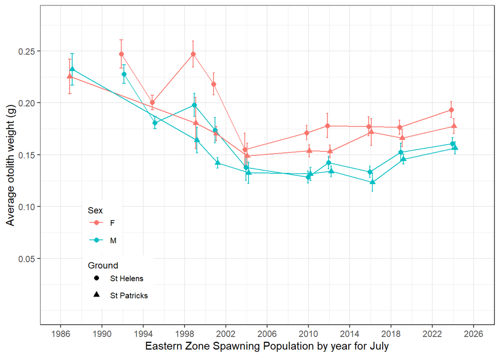

```r
pd <- position_dodge(0.5) # move position horizontally b/c of overlap

f2.7 <- ggplot(O_Sum, aes(x = Year,y = O, shape = Ground, colour = Sex)) +
  geom_errorbar(aes(ymin = O - ci, ymax= O + ci),
                width =.7, position = pd) +
  geom_point( position = pd, size = 2)+
  geom_line(position = pd) +
  xlab("Eastern Zone Spawning Population by year for July")+
  ylab("Average otolith weight (g)")+
  scale_y_continuous(breaks = seq(.05,0.3,.05),limits = c(0,0.28))+
  scale_x_continuous(limits = c(1986,2026), breaks = seq(1986,2026,4))+
  theme_bw()+
  theme(legend.position = c(.25, .05),
        legend.justification = c(1,0),
        legend.text =element_text(size=8),
        legend.title = element_text(size = 9, margin = margin(t=.05)),
        legend.spacing.y =unit(.05,'cm'),
        plot.background = element_rect(linetype =  "solid") )


f2.8 <- ggplot(Age_Sum, aes(x = Year,y = Age, shape = Ground, colour = Sex)) +
  geom_errorbar(aes(ymin = Age - ci, ymax= Age + ci),
                width =.7, position = pd) +
  geom_point( position = pd, size = 2)+
  geom_line(position = pd) +
  xlab("Eastern Zone Spawning Population by year for July")+
  ylab("Average age (years)")+
  scale_y_continuous(breaks = seq(20,70,10),limits = c(20,70))+
  scale_x_continuous(limits = c(1986,2020), breaks = seq(1986,2020,4))+
  theme_bw()+
  theme(legend.position = c(.25, .05),
        legend.justification = c(1,0),
        legend.text =element_text(size=8),
        legend.title = element_text(size = 9, margin = margin(t=.05)),
        legend.spacing.y =unit(.05,'cm'),
        plot.background = element_rect(linetype =  "solid") )

plot(f2.7)
```

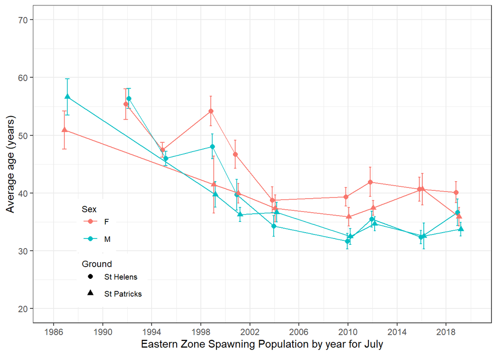

```r
ggsave("Figures/Age_owgt.emf")
ggsave("Figures/Age_owgt.jpg")
plot(f2.8)
```

```r
ggsave("Figures/Age_years.emf")
ggsave("Figures/Age_owgt.jpg")
```

### Figure 2.9 Otolith weight by year

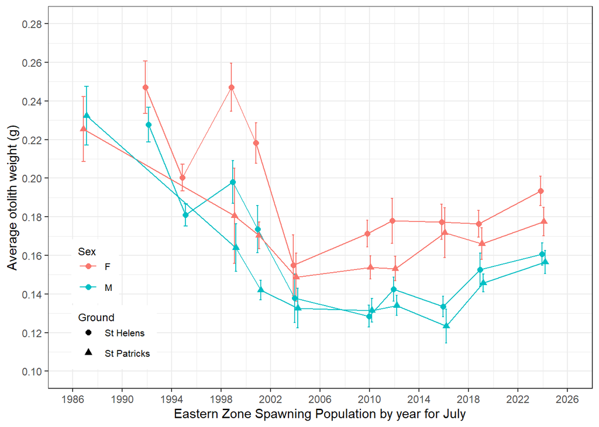

```r
O_Sum <- summarySE(Age_2, measurevar = "O", groupvars = c("Year","Ground","Sex"),na.rm = TRUE)

# Otolith Weight vs time series
f2.9 <- ggplot(O_Sum, aes(x = Year,y = O, shape = Ground, colour = Sex)) +
  geom_errorbar(aes(ymin = O - ci, ymax= O + ci),
                width =.7, position = pd) +
  geom_point( position = pd, size = 2)+
  geom_line(position = pd) +
  xlab("Eastern Zone Spawning Population by year for July")+
  ylab("Average otolith weight (g)")+
  scale_y_continuous(breaks = seq(.1,0.28,.02),limits = c(.1,0.28))+
  scale_x_continuous(limits = c(1986,2026), breaks = seq(1986,2026,4))+
  theme_bw()+
  theme(legend.position = c(.2, .05),
        legend.justification = c(1,0),
        legend.text =element_text(size=8),
        legend.title = element_text(size = 9, margin = margin(t=.05)),
        legend.spacing.y =unit(.05,'cm'),
        plot.background = element_rect(linetype =  "solid") )
plot(f2.9)
```

```r
ggsave("Figures/Age_Owgt.emf")
ggsave("Figures/Age_Owgt.jpg")
write.csv(Age_2,"Results/RoughyEZ_AgeIndex_1986to2024.csv")
```

### Age regression

```r
AgeRegression <- summarySE(Age_2, measurevar = "Age", groupvars = c("Year","Sex", "Ground"),na.rm = TRUE)
```

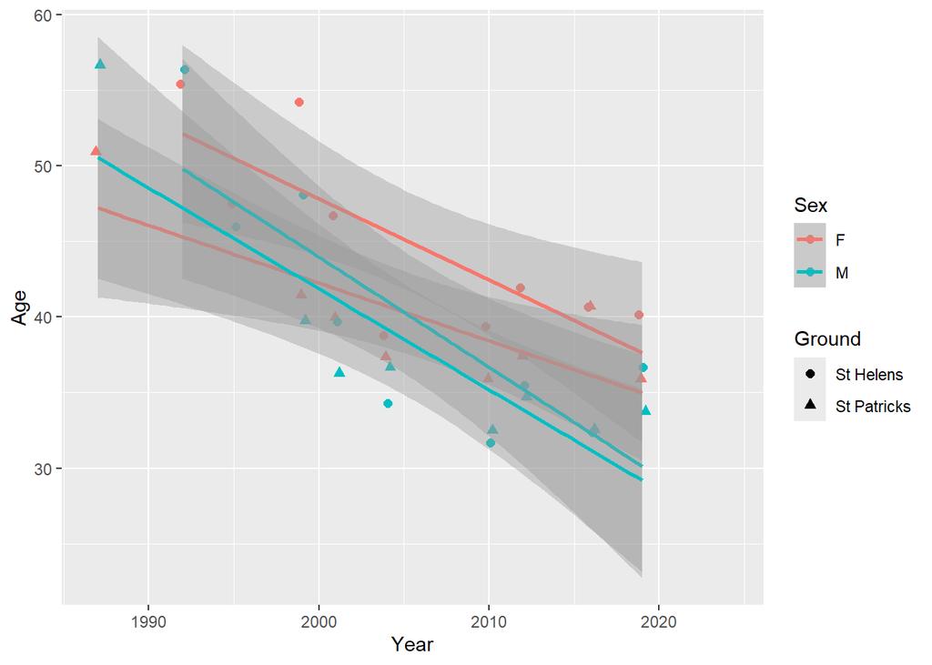

```r
ggplot(AgeRegression, aes(x = Year,y = Age, colour = Sex, shape = Ground)) +
#ggplot(AgeRegression, aes(x = Year,y = Age)) +
  # geom_errorbar(aes(ymin = O - ci, ymax= O + ci),
  #               width =.7, position = pd) +
  geom_point( position = pd, size = 2)+
  geom_smooth(method='lm')
```

Regression for data up to 2019 by sex and ground

```r
A_SHF <- AgeRegression %>%
  filter(Sex == "F") %>%
  filter(Ground == "St Helens")

A_SHM <- AgeRegression %>%
  filter(Sex == "M") %>%
  filter(Ground == "St Helens")

A_SPF <- AgeRegression %>%
  filter(Sex == "F") %>%
  filter(Ground == "St Patricks")

A_SPM <- AgeRegression %>%
  filter(Sex == "M") %>%
  filter(Ground == "St Patricks")

regression_shf <- lm(Age ~ Year , data = A_SHF)
regression_shm <- lm(Age ~ Year , data = A_SHM)
regression_spf <- lm(Age ~ Year , data = A_SPF)
regression_spm <- lm(Age ~ Year , data = A_SPM)

#Short summary of the model


#Longer summary of the model
summary(regression_shf)
```

```
##
## Call:
## lm(formula = Age ~ Year, data = A_SHF)
##
## Residuals:
##     Min      1Q  Median      3Q     Max
## -6.8841 -3.0083  0.5333  2.4895  5.8487
##
## Coefficients:
##              Estimate Std. Error t value Pr(>|t|)
## (Intercept) 1119.2230   311.0353   3.598  0.00876 **
## Year          -0.5357     0.1551  -3.454  0.01064 *
## ---
## Signif. codes:  0 '***' 0.001 '**' 0.01 '*' 0.05 '.' 0.1 ' ' 1
##
## Residual standard error: 4.139 on 7 degrees of freedom
##   (1 observation deleted due to missingness)
## Multiple R-squared:  0.6302, Adjusted R-squared:  0.5774
## F-statistic: 11.93 on 1 and 7 DF,  p-value: 0.01064
```

```r
summary(regression_shm)
```

```
##
## Call:
## lm(formula = Age ~ Year, data = A_SHM)
##
## Residuals:
##     Min      1Q  Median      3Q     Max
## -6.7454 -3.5127  0.0701  3.3973  6.5910
##
## Coefficients:
##              Estimate Std. Error t value Pr(>|t|)
## (Intercept) 1500.1522   384.6060   3.900  0.00590 **
## Year          -0.7281     0.1918  -3.796  0.00675 **
## ---
## Signif. codes:  0 '***' 0.001 '**' 0.01 '*' 0.05 '.' 0.1 ' ' 1
##
## Residual standard error: 5.118 on 7 degrees of freedom
##   (1 observation deleted due to missingness)
## Multiple R-squared:  0.6731, Adjusted R-squared:  0.6264
## F-statistic: 14.41 on 1 and 7 DF,  p-value: 0.006747
```

```r
summary(regression_spf)
```

```
##
## Call:
## lm(formula = Age ~ Year, data = A_SPF)
##
## Residuals:
##     Min      1Q  Median      3Q     Max
## -3.3560 -2.0513 -0.7032  1.6161  4.5522
##
## Coefficients:
##             Estimate Std. Error t value Pr(>|t|)
## (Intercept) 805.7288   226.1618   3.563   0.0119 *
## Year         -0.3817     0.1127  -3.386   0.0147 *
## ---
## Signif. codes:  0 '***' 0.001 '**' 0.01 '*' 0.05 '.' 0.1 ' ' 1
##
## Residual standard error: 3.108 on 6 degrees of freedom
##   (1 observation deleted due to missingness)
## Multiple R-squared:  0.6565, Adjusted R-squared:  0.5992
## F-statistic: 11.47 on 1 and 6 DF,  p-value: 0.01475
```

```r
summary(regression_spm)
```

```
##
## Call:
## lm(formula = Age ~ Year, data = A_SPM)
##
## Residuals:
##     Min      1Q  Median      3Q     Max
## -4.9156 -2.7113 -0.8439  2.1697  6.1245
##
## Coefficients:
##              Estimate Std. Error t value Pr(>|t|)
## (Intercept) 1375.8668   306.4443   4.490  0.00415 **
## Year          -0.6670     0.1528  -4.366  0.00474 **
## ---
## Signif. codes:  0 '***' 0.001 '**' 0.01 '*' 0.05 '.' 0.1 ' ' 1
##
## Residual standard error: 4.211 on 6 degrees of freedom
##   (1 observation deleted due to missingness)
## Multiple R-squared:  0.7606, Adjusted R-squared:  0.7207
## F-statistic: 19.06 on 1 and 6 DF,  p-value: 0.004738
```

Regression for recent data

```r
Age_recent <- AgeRegression %>%
  filter(Sex == "F" & Ground == "St Helens") %>%
  filter(Year >= 2010)

  distinct(Age_recent, Year)
```

```
##   Year
## 1 2010
## 2 2012
## 3 2016
## 4 2019
## 5 2024
```

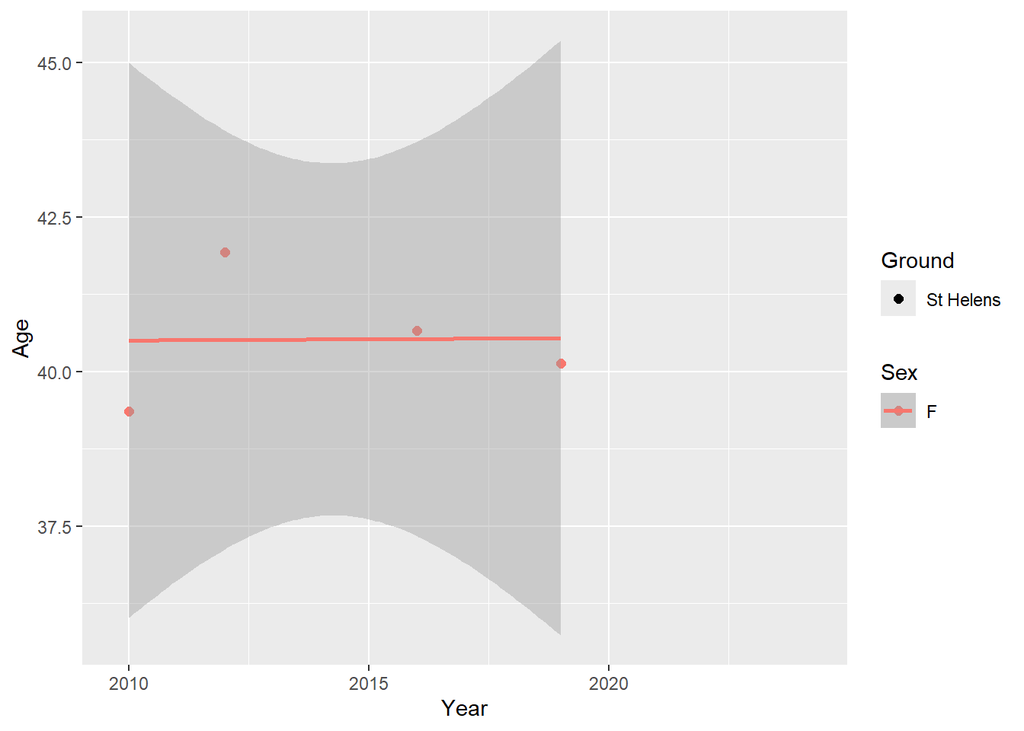

```r
ggplot(Age_recent, aes(x = Year,y = Age, colour = Sex, shape = Ground)) +
  # geom_errorbar(aes(ymin = O - ci, ymax= O + ci),
  #               width =.7, position = pd) +
  geom_point( position = pd, size = 2)+
  geom_smooth(method='lm')
```

```r
regression_recent <- lm(Age ~ Year, data = Age_recent)


#Longer summary of the model
summary(regression_recent)
```

```
##
## Call:
## lm(formula = Age ~ Year, data = Age_recent)
##
## Residuals:
##       1       2       3       4
## -1.1470  1.4165  0.1357 -0.4052
##
## Coefficients:
##             Estimate Std. Error t value Pr(>|t|)
## (Intercept)  32.4664   381.8844   0.085    0.940
## Year          0.0040     0.1896   0.021    0.985
##
## Residual standard error: 1.324 on 2 degrees of freedom
##   (1 observation deleted due to missingness)
## Multiple R-squared:  0.0002225,  Adjusted R-squared:  -0.4997
## F-statistic: 0.000445 on 1 and 2 DF,  p-value: 0.9851
```

results SH F, Year 0.0040  
SH M, Year 0.3357 SP F, Year 0.1016 NS SP M, Year 0.02392 NS

checking Rudy’s statistics.. all good :)

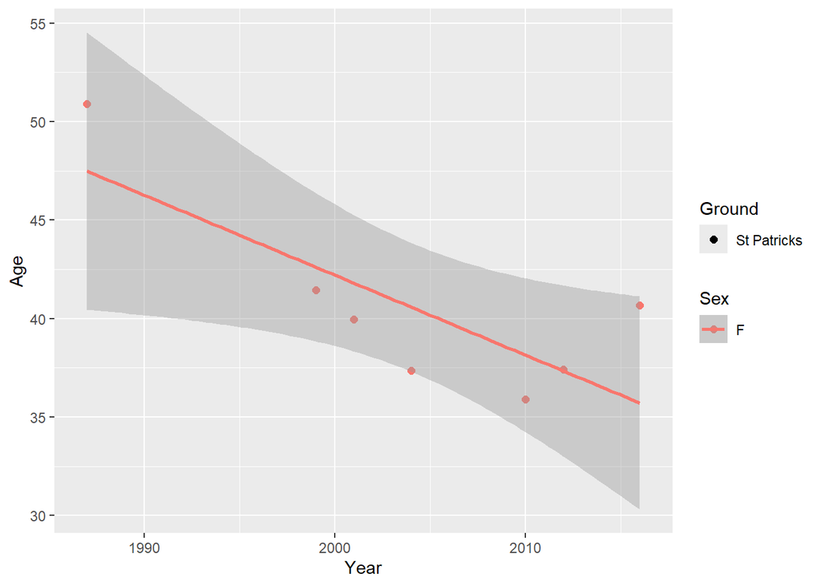

```r
Age_2016 <- AgeRegression %>%
  filter(Year <= 2016)%>%
  #filter(Year >= 2010) %>%
  filter(Sex == "F" & Ground == "St Patricks")

ggplot(Age_2016, aes(x = Year,y = Age, colour = Sex, shape = Ground)) +

  # geom_errorbar(aes(ymin = O - ci, ymax= O + ci),
  #               width =.7, position = pd) +
  geom_point( position = pd, size = 2)+
  geom_smooth(method='lm')
```

```r
#regression_2016 <- lm(Age ~ Year + Sex + Ground, data = Age_2016)
regression_2016 <- lm(Age ~ Year, data = Age_2016)

#Longer summary of the model
summary(regression_2016)
```

```
##
## Call:
## lm(formula = Age ~ Year, data = Age_2016)
##
## Residuals:
##        1        2        3        4        5        6        7
##  3.42559 -1.17011 -1.83895 -3.22811 -2.24923  0.09166  4.96915
##
## Coefficients:
##             Estimate Std. Error t value Pr(>|t|)
## (Intercept) 853.8737   283.3825   3.013   0.0296 *
## Year         -0.4058     0.1414  -2.870   0.0350 *
## ---
## Signif. codes:  0 '***' 0.001 '**' 0.01 '*' 0.05 '.' 0.1 ' ' 1
##
## Residual standard error: 3.366 on 5 degrees of freedom
## Multiple R-squared:  0.6223, Adjusted R-squared:  0.5468
## F-statistic: 8.238 on 1 and 5 DF,  p-value: 0.03499
```

### compare ototlith weight between 2019 and 2024

```r
Owgt_2024 <- Age_2 %>%
  filter(Year == 2019 | Year == 2024)
  #filter(Year == 2019 | Year == 2016)
  #filter(Year >= 2010) %>%

Owgt_2024 %>%

  dplyr::group_by(Year,Sex) %>%

  dplyr::group_by(Sex) %>%

  dplyr::summarise(mean(O,na.rm = TRUE),mean(Age,na.rm = TRUE), n())
```

```
## # A tibble: 2 × 4
##   Sex   `mean(O, na.rm = TRUE)` `mean(Age, na.rm = TRUE)` `n()`
##   <chr>                   <dbl>                     <dbl> <int>
## 1 F                       0.180                      38.6   984
## 2 M                       0.154                      34.9   750
```

```r
#regression_2016 <- lm(Age ~ Year + Sex + Ground, data = Age_2016)
regression_Owgt_2024 <- lm(O ~ Year + Sex + Ground, data = Owgt_2024)

#Longer summary of the model
summary(regression_Owgt_2024)
```

```
##
## Call:
## lm(formula = O ~ Year + Sex + Ground, data = Owgt_2024)
##
## Residuals:
##      Min       1Q   Median       3Q      Max
## -0.09114 -0.03214 -0.00899  0.01937  0.40122
##
## Coefficients:
##                     Estimate Std. Error t value Pr(>|t|)
## (Intercept)       -4.7925866  1.0349193  -4.631 3.94e-06 ***
## Year               0.0024616  0.0005119   4.809 1.66e-06 ***
## SexM              -0.0249435  0.0025989  -9.598  < 2e-16 ***
## GroundSt Patricks -0.0096413  0.0025903  -3.722 0.000205 ***
## ---
## Signif. codes:  0 '***' 0.001 '**' 0.01 '*' 0.05 '.' 0.1 ' ' 1
##
## Residual standard error: 0.05074 on 1580 degrees of freedom
##   (150 observations deleted due to missingness)
## Multiple R-squared:  0.0826, Adjusted R-squared:  0.08086
## F-statistic: 47.42 on 3 and 1580 DF,  p-value: < 2.2e-16
```

### compare age between 2016 and 2019

```r
Owgt_2024 <- Age_2 %>%
  filter(Year == 2019 | Year == 2016)
  #filter(Year == 2019 | Year == 2016)
  #filter(Year >= 2010) %>%

Owgt_2024 %>%
  dplyr::group_by(Ground, Sex, Year) %>%
  dplyr::summarise(mean(O,na.rm = TRUE),mean(Age,na.rm = TRUE), n())
```

```
## # A tibble: 8 × 6
## # Groups:   Ground, Sex [4]
##   Ground      Sex    Year `mean(O, na.rm = TRUE)` mean(Age, na.rm = TRUE…¹ `n()`
##   <chr>       <chr> <dbl>                   <dbl>                    <dbl> <int>
## 1 St Helens   F      2016                   0.177                     40.7   242
## 2 St Helens   F      2019                   0.176                     40.1   301
## 3 St Helens   M      2016                   0.134                     32.4   204
## 4 St Helens   M      2019                   0.153                     36.7   142
## 5 St Patricks F      2016                   0.172                     40.7    96
## 6 St Patricks F      2019                   0.166                     35.9   173
## 7 St Patricks M      2016                   0.123                     32.6    43
## 8 St Patricks M      2019                   0.146                     33.8   209
## # ℹ abbreviated name: ¹`mean(Age, na.rm = TRUE)`
```

```r
#regression_2016 <- lm(Age ~ Year + Sex + Ground, data = Age_2016)
regression_Owgt_2024 <- lm(Age ~ Year + Sex + Ground, data = Owgt_2024)

#Longer summary of the model
summary(regression_Owgt_2024)
```

```
##
## Call:
## lm(formula = Age ~ Year + Sex + Ground, data = Owgt_2024)
##
## Residuals:
##    Min     1Q Median     3Q    Max
## -20.64  -7.38  -2.38   3.62 103.79
##
## Coefficients:
##                     Estimate Std. Error t value Pr(>|t|)
## (Intercept)       -133.97605  486.90623  -0.275   0.7832
## Year                 0.08627    0.24135   0.357   0.7208
## SexM                -5.56725    0.71019  -7.839 9.35e-15 ***
## GroundSt Patricks   -1.74119    0.75058  -2.320   0.0205 *
## ---
## Signif. codes:  0 '***' 0.001 '**' 0.01 '*' 0.05 '.' 0.1 ' ' 1
##
## Residual standard error: 12.67 on 1308 degrees of freedom
##   (98 observations deleted due to missingness)
## Multiple R-squared:  0.05101,    Adjusted R-squared:  0.04883
## F-statistic: 23.43 on 3 and 1308 DF,  p-value: 8.928e-15
```